# Projekt z eksploracji danych

Autor

Igor Nowiński

# Cel badania

Celem badania jest zbudowanie optymalnego modelu klasyfikacyjnego, którego zadaniem będzie analiza predyktorów i na jej podstawie określenie ogólnej oceny przejazdu.

# Opis zbioru danych

## Wprowadzenie

Zbiór danych został zebrany na podstawie aplikacji Go!Track. Jest on dostępny na stronie [Uniwersytetu Kalifornijskiego w Irvine](https://archive.ics.uci.edu/dataset/354/gps+trajectories). Aplikacja pełniła rolę nawigatora GPS oraz służyła do szukania przewoźników. Dostępna ona była w sklepie [Google Play](https://web.archive.org/web/20170719115511/https://play.google.com/store/apps/details?id=com.go.router). Zbiór danych posiada 163 obserwacje i składa się z 10 zmiennych.

[figure not shown]

## Opis zmiennych

`id_android` - numer identyfikacyjny urządzenia z którego pochodzą dane

`speed` - średnia prędkość pojazdy w kilometrach na godzinę

`distance` - dystans przejechany, liczony w kilometrach

`time` - czas podróży, liczony w godzinach

`rating` - zmienna nominalna, która przyjmuje 3 wartości. Jest to ogólna ocena przejazdu przez pasażera 1 - źle, 2 - w porządku, 3 - dobrze

`rating_bus` - zmienna nominalna, określa poziom zatłoczenia w pojeździe 1 - mało pasażerów, 2 - pojazd nie jest przepełniony, 3 - pojazd jest przepełniony

`rating_weather` - określa, jaka była pogoda podczas podróży 1 - deszczowo, 2 - słonecznie

`car_or_bus` - czy pasażer podróżował samochodem, czy autobusem 1 - samochód, 2 - autobus

`linha` - informacja na temat pojazdu

Tabela 1: Przykładowe wartości zmiennych w zbiorze danych

| id | id_android | speed | time | distance | rating | rating_bus | rating_weather | car_or_bus | linha |
| --- | --- | --- | --- | --- | --- | --- | --- | --- | --- |
| 1 | 0 | 19.210586 | 0.138048889 | 2.652 | 3 | 0 | 0 | 1 |  |
| 2 | 0 | 30.848229 | 0.171484722 | 5.290 | 3 | 0 | 0 | 1 |  |
| 3 | 1 | 13.560101 | 0.067698611 | 0.918 | 3 | 0 | 0 | 2 |  |
| 4 | 1 | 19.766679 | 0.389544444 | 7.700 | 3 | 0 | 0 | 2 |  |
| 8 | 0 | 25.807401 | 0.154800556 | 3.995 | 2 | 0 | 0 | 1 |  |
| 10 | 2 | 1.346913 | 0.006681944 | 0.009 | 2 | 0 | 0 | 1 |  |

## Czyszczenie danych

Ponieważ zbiór danych zawiera identyfikatory, do przeprowadzenia analizy zdecydowałem się usunąć kolumny `id` i `id_android`. Dodatkowo usuwam również kolumnę `linha`, ponieważ jest typu *chr*.

Tabela 2: Przykładowe wartości zmiennych w zbiorze danych po usunięciu kolumn id, id_android i linha

| speed | time | distance | rating | rating_bus | rating_weather | car_or_bus |
| --- | --- | --- | --- | --- | --- | --- |
| 19.210586 | 0.138048889 | 2.652 | 3 | 0 | 0 | 1 |
| 30.848229 | 0.171484722 | 5.290 | 3 | 0 | 0 | 1 |
| 13.560101 | 0.067698611 | 0.918 | 3 | 0 | 0 | 2 |
| 19.766679 | 0.389544444 | 7.700 | 3 | 0 | 0 | 2 |
| 25.807401 | 0.154800556 | 3.995 | 2 | 0 | 0 | 1 |
| 1.346913 | 0.006681944 | 0.009 | 2 | 0 | 0 | 1 |

### Sprawdzenie braków danych

Tabela 3: Sprawdzenie występowania wartości NA w zbiorze danych

| speed | time | distance | rating | rating_bus | rating_weather | car_or_bus |
| --- | --- | --- | --- | --- | --- | --- |
| 0 | 0 | 0 | 0 | 0 | 0 | 0 |

Na podstawie Tabela 3 mogę stwierdzić, że nie ma wartości NA w zbiorze danych.

Przedstawienie liczebności zmiennej rating_bus, rating_weather oraz rating

| Poziom | Liczebność |
| --- | --- |
| 0 | 116 |
| 1 | 34 |
| 2 | 10 |
| 3 | 3 |

| Poziom | Liczebność |
| --- | --- |
| 0 | 116 |
| 1 | 10 |
| 2 | 37 |

| Poziom | Liczebność |
| --- | --- |
| 1 | 17 |
| 2 | 45 |
| 3 | 101 |

Niestety zmienne `rating_bus` i `rating_weather` posiadają wiele wartości 0, co oznaczają braki danych. Zamieniam je na wartości *NA*.

Zbiór danych posiada 116 niepełnych obserwacji.

## Wizualizacja zbioru danych

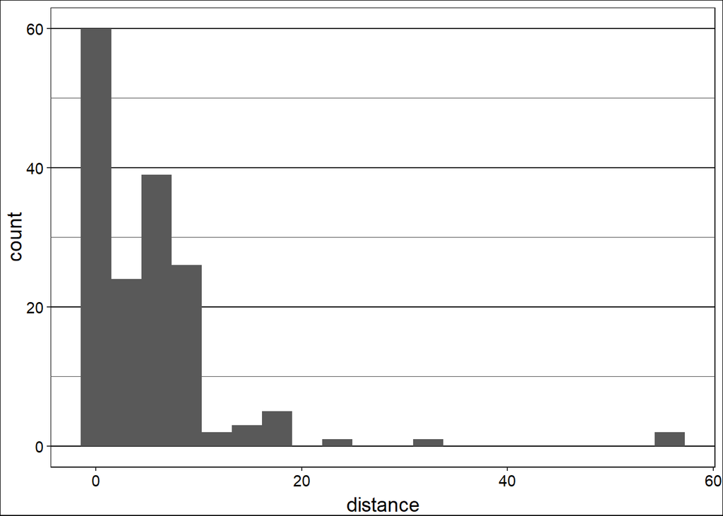

Rysunek 1: Rozkład częstotliwości występowania wartości zmiennej distance

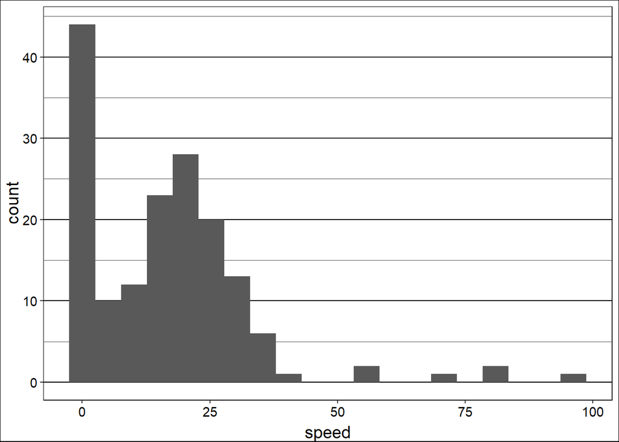

Rysunek 2: Rozkład częstotliwości występowania wartości zmiennej speed